**1**

Lalu M, *et al*. *BMJ Open* 2019;**9**:e029475. doi:10.1136/bmjopen-2019-029475

**Open access**

**Mapping the preclinical to clinical**

**evidence and development trajectory of**

**the oncolytic virus talimogene**

**laherparepvec (T- VEC): a**

**systematic review**

Manoj Lalu ,<sup>1,2,3,4</sup> Garvin J Leung,<sup>1,5</sup> Yuan Yi Dong,<sup>1,5</sup> Joshua Montroy,<sup>1</sup>

Claire Butler,<sup>1</sup> Rebecca C Auer,<sup>6,7</sup> Dean A Fergusson<sup>1,5,8</sup>

**To cite:** Lalu M, Leung GJ,

Dong YY, *et al*. Mapping the

preclinical to clinical evidence

and development trajectory of

the oncolytic virus talimogene

laherparepvec (T- VEC): a

systematic review. *BMJ Open*

2019;**9**:e029475. doi:10.1136/

bmjopen-2019-029475

► Prepublication history and

additional material for this paper

are available online. To view

please visit the journal (http://

dx. doi. org/ 10. 1136/ bmjopen-

2019- 029475).

ML and GJL contributed equally.

Received 30 January 2019

Revised 01 November 2019

Accepted 04 November 2019

For numbered affiliations see

end of article.

**Correspondence to**

Dr Dean A Fergusson;

dafergusson@ ohri. ca

**Original research**

© Author(s) (or their

employer(s)) 2019. Re- use

permitted under CC BY- NC. No

commercial re- use. See rights

and permissions. Published by

BMJ.

**AbstrACt**

**Objective** This study aimed to conduct a systematic

review of preclinical and clinical evidence to chart the

successful trajectory of talimogene laherparepvec (T- VEC)

from the bench to the clinic.

**Design** This study was a systematic review. The primary

outcome of interest was the efficacy of treatment,

determined by complete response. Abstract and full- text

selection as well as data extraction were done by two

independent reviewers. The Cochrane risk of bias tool was

used to assess the risk of bias in studies.

**setting** Embase, Embase Classic and OvidMedline were

searched from inception until May 2016 to assess its

development trajectory to approval in 2015.

**Participants** Preclinical and clinical controlled

comparison studies, as well as observational studies.

**Interventions** T- VEC for the treatment of any malignancy.

**results** 8852 records were screened and five preclinical

(n=150 animals) and seven clinical studies (n=589

patients) were included. We saw large decreases in T-

VEC’s efficacy as studies moved from the laboratory to

patients, and as studies became more methodologically

rigorous. Preclinical studies reported complete regression

contralateral tumours, while the highest degree of efficacy

seen in the clinical setting was a 24% complete response

rate, with one study experiencing a complete response

rate of 0%. We were unable to reliably assess safety due to

the lack of reporting, as well as the heterogeneity seen in

adverse event definitions. All preclinical studies had high or

unclear risk of bias, and all clinical studies were at a high

risk of bias in at least one domain.

**Conclusions** Our findings illustrate that even successful

biotherapeutics may not demonstrate a clear translational

road map. This emphasises the need to consider

increasing rigour and transparency along the translational

pathway.

**PrOsPErO registration number** CRD42016043541.

**bACkgrOunD**

Preclinical research receives approximately

half of the world’s biomedical research

funding, yet very few of its findings translate

clinically. This represents an enormous waste

of resources with an estimated US$28 billion

dollars per year in the USA alone being spent

on biomedical research which is not repro-

ducible and therefore not translatable.<sup>1</sup> One

study found that only 5% of highly efficacious

preclinical therapeutics were clinically trans-

lated.<sup>2</sup> These successes often take almost 20

years to become successfully translated across

the research spectrum.<sup>2 3</sup>

Although the process of clinical trans-

lation is complicated, the transition from

bench- to- bedside often starts with preclinical

research. These investigations (usually on

animals or cells) are aimed at studying effi-

cacy, pharmacokinetics and dynamics, as well

as detailing safety.<sup>4</sup> Next, a drug is tested in a

phase I clinical trial, which usually contains a

small number of participants and is aimed at

studying the safety of the drug. If a drug is safe,

it may proceed to phase II studies which are

larger than phase I studies and are designed

to test safety, pharmacokinetics, pharmacody-

namics and optimal dosing regimens. They

may also offer preliminary evidence of drug

efficacy. Finally, a methodologically rigorous

phase III study is performed. These studies

are designed and powered to test efficacy in

the patient population of interest (usually

against a comparator such as placebo), as

**strengths and limitations of this study**

► Comprehensive analysis of the translational path-

way of talimogene laherparepvec.

► Threats to both internal validity and construct valid-

ity were assessed.

► Reporting of methods and findings was incomplete

in most of the studies included, which limited our

analysis

**2**

Lalu M, *et al*. *BMJ Open* 2019;**9**:e029475. doi:10.1136/bmjopen-2019-029475

**Open access**

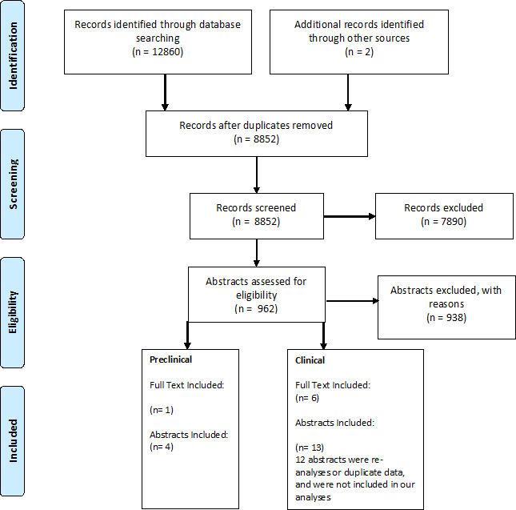

**Figure 1** Study selection flow diagram.

well as identify rarer adverse events which may have gone

unnoticed in a smaller phase I or II study.<sup>5</sup>

Given the high failure rate in translating therapies

across this spectrum, as well as significant time- lags associ-

ated with translation, it is important that we examine the

few agents that have successfully crossed the preclinical to

clinical bridge in order to learn from and replicate their

success. Thus, we conducted a comprehensive evaluation

of available evidence supporting the successful transla-

tion of talimogene laherparepvec (T- VEC). T- VEC is a

modified Herpes Simplex Virus (HSV)-1 virus produced

by Amgen and it is the first, and only, Food and Drug

Adminstration (FDA) approved oncolytic virus therapy;

it is currently approved to treat advanced melanoma.<sup>6</sup>

Oncolytic viruses are an emerging cancer therapy that

work by preferentially targeting and infecting cancer

cells.<sup>6</sup> On infection, oncolytic viruses can induce an anti-

tumour immune response that reduces tumour burden.

T- VEC was chosen as a model due to the fact that it is the

only approved oncolytic virus therapy to date, despite the

multitude of agents under investigation.<sup>7</sup>

Through a careful evaluation of T- VEC development,

we hoped to identify factors that may contribute to bench-

to- bedside success. This may serve an exemplar for other

therapies as they move along the translational continuum.

Thus, the purpose of this systematic review was to map

the successful preclinical to clinical trajectory of T- VEC to

inform the development paths of future biotherapeutics.

**MEthODs**

Our review was registered in full on PROSPERO,the inter-

national prospective register of systematic reviews (no.

CRD42016043541). The review is reported in accordance

to the Preferred Reporting Items for Systematic Review

and Meta- Analysis (PRISMA) guidelines.<sup>8</sup>

**Eligibility criteria**

We included all clinical and preclinical in vivo controlled

comparison studies of T- VEC for treatment of any

malignancy (randomised, pseudo- randomised and non-

randomised studies), as well as observational studies

such as case- control, case- series and case reports. Studies

reporting only ex vivo or in vitro experiments were

excluded. For both preclinical and clinical studies, we

included studies that administered T- VEC as a mono-

therapy or in combination with other therapies for treat-

ment of malignancy. We had no exclusions on comparison

treatments, which include standard line therapy or no

treatment.

**3**

Lalu M, *et al*. *BMJ Open* 2019;**9**:e029475. doi:10.1136/bmjopen-2019-029475

**Open access**

**Table 1** Study characteristics of included preclinical studies of T- VEC

**Preclinical study**

**Treatment**

**Total number of**

**animals used**

**Type of cancer/model**

**Efficacy measures***

**Risk of**

**bias (/9****†****)**

Liu *et al*<sup>20</sup>

T- VEC; HSV1 wild

type immunisation

90

Lymphoma (A20 murine

lymphoma mouse model)

CR: 100% (n=10) (injected)

Piasecki *et al*<sup>21</sup>

T- VEC

NR

Lymphoma (A20 murine

lymphoma mouse model)

CR: 70%–100% of injected,

50%–60% of contralateral

9

Piasecki *et al*<sup>23</sup>

T- VEC +Anti- PD-1

NR

Colorectal (MC-38 colon

carcinoma mouse model)

CR: 80.0% (44.2%–96.5%)

(injected) n=10

CR: 20.0% (3.5%–55.8%)

(contralateral) n=10

9

Cooke *et al*<sup>22</sup>

T- VEC

40

Lymphoma (A20 murine

lymphoma mouse model)

CR: 100% (65.5%–100%)

(injected) n=10

CR: 50% (23.7%–76.3%)

(contralateral)

9

Cooke *et al*<sup>24</sup>

T- VEC

20

Melanoma (B16F10

melanoma model)

NR: statistically significant

tumour reduction and

survival noted

9

* DR – durable response; OR – objective response; CR – complete response/complete regression; PR – partial response;DR/OR/CR/PR

definitions were based on RECIST guidelines for clinical studies. † Total number of domains that were assessed a score of high risk or

unclear (maximum = 9).

CR, complete response; HSV, Herpes Simplex Virus; NR, Not reported; PR, partial response; T- VEC, talimogene laherparepvec.

**Outcomes**

The primary outcome of interest was the efficacy of treat-

ment. Our primary indicator of efficacy was complete

response. Other measures of efficacy such as survival,

response rates (durable, partial, objective), time to treat-

ment failure and disease stability were also collected. Such

measures were based on the Response Evaluation Criteria

in Solid Tumours Guidelines.<sup>9</sup> In preclinical studies, addi-

tional measures of efficacy such as changes in mean tumour

volume and number of lesions were collected. The primary

indicator of efficacy, complete response, was used as the

primary outcome regardless of reporting within the indi-

vidual study, in order to assess the continuity of evidence

along the research spectrum. The secondary outcome of

interest was safety, for which we collected data on all adverse

events in preclinical and clinical studies.

**Literature search**

In collaboration with a medical information specialist

(Risa Shorr, Learning Services, The Ottawa Hospital)

a search strategy was designed to identify all relevant

preclinical and clinical studies. Searches were conducted

in the following databases: Embase, Embase Classic and

OvidMedline from inception until May 2016. This time

frame was chosen to ensure that all published studies

which contributed T- VECs FDA approval in 2015 were

included. Search terms included Talimogen laher-

parepvec, Tvec, OncoVEX and Imlygic. Additional terms

pertaining to preclinical studies (eg, animal experiment/

model) and oncology (eg, cancer, neoplasm, oncolytic

virus) were also included. Studies were also screened

for inclusion based on reference tracking, by scanning

the bibliography of included primary studies and rele-

vant review articles. We did not impose any restrictions

on language or publication type. A grey literature search

was not performed. The finalised search strategy can be

found in online supplementary file 1.

**study selection process**

Studies identified by our literature search were collated and

duplicates were removed. Titles and abstracts were inde-

pendently screened for inclusion by two reviewers using

DistillerSR (Evidence Partners, Ottawa, Ontario, Canada).

Those deemed potentially relevant were recorded, and full-

text articles were obtained. The same reviewers screened

full articles for final eligibility. Disagreements at any stage

were resolved by discussion or consultation with a senior

team member when necessary. The study selection process

was documented using a PRISMA flow diagram.

**Data extraction**

All data extraction was completed independently and in

duplicate, using a standardised and piloted data extraction

form, with disagreements resolved as mentioned above.

Data pertaining to general and intervention characteristics

of the included studies were extracted (eg, study design,

country, type of malignancy, dosing of intervention and

comparator treatments). For clinical studies, data was

collected on patient characteristics (eg, age, sex, cancer

staging, HSV status). For preclinical studies, characteristics

on the animal model were extracted (eg, type of species,

cell line used, disease induction method, age, sex, weight).

**risk of bias: assessment to risk of internal validity**

Clinical studies that met inclusion criteria were assessed for

risk of bias in duplicate, according to the recommended

methodology of the Cochrane Collaboration.<sup>10</sup> Five

types of biases (selection, performance, detection, attri-

tion, reporting biases) were assessed using six domains:

**4**

Lalu M, *et al*. *BMJ Open* 2019;**9**:e029475. doi:10.1136/bmjopen-2019-029475

**Open access**

randomisation, allocation concealment, blinding of partic-

ipants/personnel, outcome assessment blinding, incom-

plete outcome reporting and selective outcome reporting.

Additional domains assessed for risk of bias were (1)

reported conflicts of interest, (2) sample size calculation

and (3) funding. Each domain was given a score of ‘high’,

‘unclear’ or ‘low’ risk of bias for each study. Risk of bias

assessment for preclinical studies were assessed using a

modified Cochrane Risk of Bias tool and assessed the same

domains as indicated for clinical studies.<sup>11</sup>

**Assessment of threats to construct validity**

Construct validity is the concept in how well a preclinical

experiment (ie, animal studies) corresponds to the clinical

entity it is intended to model. There are various threats to

construct validity that can be introduced from the preclin-

ical study design. The items evaluated in duplicate for

each preclinical study include (1) use of adult animals,

(2) use of animals with advanced stage disease (defined as

the presence of multiple visceral lesions and/or clinical/

histological signs of malignant progression), (3) immune

status of animals to HSV, (4) whether a xenograft model

was used and (5) the use of a humanised immune system

model. Each of these items was given a score of ‘yes’, ‘no’ or

‘unclear’ for every preclinical study.

**statistical analysis**

Efficacy was expressed as proportions with accompanying

95% CIs. If CIs were not present within the individual study,

they were calculated via standard methods.<sup>12</sup> To assess the

continuity between preclinical and clinical studies, the effi-

cacy of studies was plotted as percentage response.

**Deviations from protocol**

We were unable to assess safety as we could not acquire

patient- level safety data. Furthermore, our primary efficacy

outcome stated in the protocol was durable response rate.

However, this was changed to complete response as most

clinical studies did not report durable response, and we

needed to track T- VEC’s trajectory over several studies. We

acknowledge the limitation of this approach, given the FDA

approved T- VEC based on the OPTIM trial,<sup>13</sup> the primary

endpoint of which was durable response rate. Subgroup

analyses, meta- analyses, Egger’s test and pooling of data

could not be conducted due to the limited available data.

**Patient and public involvement**

Patients and the public were not involved in this research.

**rEsuLts**

On removal of duplicates, a total of 8852 references were

identified by the electronic search. During the review of titles

and abstracts, 7890 references were excluded. Following

full- text screening, another 938 articles were excluded

for reasons such as wrong study design (ie, review article)

or wrong study intervention (ie, a different cancer thera-

peutic). A total of seven clinical studies<sup>13–19</sup> and five preclin-

ical studies<sup>20–24</sup> were included in our review (figure 1).

**Characteristics of included trials**

Characteristics of included preclinical studies are shown

in table 1. Preclinical studies were published between

2003 and 2016 and sample sizes ranged from 20 to 90. Of

the five preclinical studies, three used a lymphoma model,

one used a colorectal model and one used a melanoma

model. All studies were performed in mice. The duration

of follow- up was reported by two studies and ranged from

10 to 35 days. The dose of T- VEC used ranged from 3×10<sup>4</sup>

plaque forming units (PFU) to 5×10<sup>6</sup> PFU. Frequency

of T- VEC administration varied: every 3 days for 1 week,

every 3 days for 9 days, a single dose given only once and

every other day for 5 days. Specific details of study and

intervention characteristics for each preclinical study can

be found in online supplementary files 2 and 3.

Characteristics of included clinical studies are shown in

table 2. Studies were published between 2006 and 2016

and took place in seven countries. Sample sizes ranged

from 17 to 295. Of the seven clinical studies, four were in

melanoma patients, one was in pancreatic cancer patients,

one in head and neck cancer patients and one studied a

mix of breast, colorectal, melanoma and head and neck

cancer patients. Six were either phase I or II, and one

trial was a phase III evaluation. The primary outcome was

efficacy in two studies, safety in three studies and a combi-

nation of efficacy and safety in the other two studies. The

duration of follow- up ranged from 6 weeks to 44 months.

T- VEC was administered alone in four studies, while it was

administered immediately following to systemic therapy in

three studies. The dose of T- VEC administered ranged from

10<sup>4</sup> to 10<sup>8</sup> PFU/mL. In the large study, phase III, T- VEC

was administered at ≤4 mL × 10<sup>6</sup> PFU/mL once, and then

3 weeks later, ≤4 mL 10<sup>8</sup> PFU/mL was administered every

2 weeks for a median of 23 weeks. A similar dosing regimen

was used in three other trials. The other three trials were

dose- finding in nature and had multiple trial arms receiving

increasing doses of T- VEC. In- depth study details, as well as

participant and intervention details for each study, can be

found in online supplementary files 4-6.

Efficacy of treatment

Treatment efficacy for each study is summarised in

table 1, table 2 and figure 2. Preclinical studies reported

complete regression rates up to 100% for injected

first published phase I T- VEC clinical trial reported a

complete response of 0% for cutaneous lesions caused

by malignancies of head and neck, breast, colorectal and

melanoma. Of the multiple malignancies treated, mela-

noma had the best response in this trial. Subsequent

phase I/II melanoma trials were then conducted and

demonstrated complete response rates of 20%–22%.

This was followed by the phase III OPTIM melanoma

trial, which had a complete response rate of 10.8%.

Studies involving non- melanoma cancers varied with

efficacies between 0% and 24%.

**5**

Lalu M, *et al*. *BMJ Open* 2019;**9**:e029475. doi:10.1136/bmjopen-2019-029475

**Open access**

**Table 2** Study characteristics of included clinical studies of T- VEC

**Clinical study**

**Treatment**

**Total N**

**Type of cancer**

**Efficacy measures***

**Risk of bias (/9****†****)**

Hu *et al*<sup>14</sup>

*Non- controlled*

phase I

T- VEC

30 (9

melanoma)

Breast, colorectal,

melanoma, head and

neck

CR: 0% (0%–14.1%)

PR: 0% (0%–14.1%)

7

Senzer *et al*<sup>15</sup>

Non- controlled

phase II

T- VEC

50

Melanoma

OR: 26.0% (15.1%–40.6%)

CR: 20.0% (10.5%–34.1%)

PR: 10.0% (3.7%–22.6%)

7

Harrington *et al*<sup>18</sup>

phase I/II

T- VEC +cisplatin

17

Head and neck

CR: 23.5% (7.8%–50.2%)

PR: 58.8% (33.5%–80.6%)

OR: 82.4% (55.8%–95.3%)

6

Chang *et al*<sup>19</sup>

phase I

T- VEC

17

Pancreatic

OR: 0% (0%–22.9%)

6

Andtbacka *et al*<sup>13</sup>

phase III

T- VEC

295

Melanoma

DR: 16.3% (12.1%–20.5%)

OR: 26.4% (21.4%–31.5%)

PR: 15.6% (11.7%–20.3%)

CR: 10.8% (7.6%–15.1%)

3

GM- CSF (control)

141

DR: 2.1% (0%–4.5%)

OR: 5.7% (1.9%–9.5%)

PR: 5.0% (1.3%–8.5%)

CR:<1%

Long *et al*<sup>16</sup>

phase Ib

T- VEC

+pembrolizumab

21

Melanoma

–

6

Puzanov *et al*<sup>17</sup>

phase Ib

T- VEC+IPI

18

Melanoma

DR: 44.4% (22.4%–68.7%)

OR: 50.0% (29.0%–70.9%)

CR: 22.2% (7.4%–48.1%)

PR: 27.8% (10.7%–53.6%)

6

*Definitions of DR/OR/CR/PR were based on RECIST guidelines for clinical studies.

†Total number of domains that were assessed a score of high risk or unclear (maximum=9). The nine domains include randomisation,

allocation concealment, blinding of participants/personnel, outcome assessment blinding, incomplete outcome reporting, selective

outcome reporting, reported conflicts of interest, sample size calculation and funding.

CR, complete response/complete regression; DR, durable response; IPI, Ipilimumab; OR, objective response; PR, partial response;

RECIST, Response Evaluation Criteria in Solid Tumours; T- VEC, talimogene laherparepvec.

Safety of treatment

We attempted to assess safety across clinical studies;

however, we were unable to obtain patient- level data from

any of the studies. The definitions of adverse events, and

the manner in which they were classified, were found to

be highly heterogenous across studies. Studies did not

specify what percent of adverse events were repeated

adverse events from the same patient(s), used different

criteria for recording and reporting adverse events, and

categorised them differently. Therefore, we were unable

to pool adverse events or interpret findings reliably.

Validity assessments

Construct validity, the concept of how well an animal

model represents the clinical entity it is intended to

mimic, was first assessed through the following domains:

the use of appropriately aged mice, advanced stage of

disease, HSV- immunity and types of mouse models. None

of the preclinical studies fully reported or used method-

ologies to reduce threats to construct validity domains

(table 3). No studies declared using adult animal models,

no studies used animals with late stage disease, only one

study used animals immune to HSV, no studies used a

xenograft model and no studies reported using an animal

model with a humanised immune system.

We also assessed internal validity (ie, risk of bias) and

found that all preclinical studies had high or unclear

risk of bias across the assessed domains: randomisation

sequence, allocation concealment, blinding, incomplete

or unclear risk of bias across at least six of nine domains,

whereas the more robust phase III OPTIM trial had the

lowest risk of bias and also the lowest efficacy of any of the

published melanoma clinical trials (table 5). Reporting of

key methodological elements was lacking.

**DIsCussIOn**

We hoped to synthesise the evidence to produce a clear

road map of T- VEC’s translation in the published liter-

ature. This would allow us to follow the journey of a

successful biotherapeutic, and potentially use this as a

blueprint for similar efforts in the future. Yet, we were

unable to paint a clear picture of how the evidence was

used in proceeding to melanoma clinical trials. Rather,

**6**

Lalu M, *et al*. *BMJ Open* 2019;**9**:e029475. doi:10.1136/bmjopen-2019-029475

**Open access**

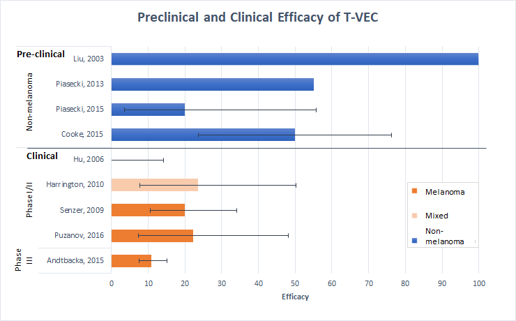

**Figure 2** Preclinical and clinical efficacy of T- VEC. Four preclinical studies using mice demonstrated efficacy rates of 20%–

100% and clinical studies (three melanoma and two mixed malignancy studies) demonstrated efficacy rates from 0% to 23.5%.

was used for clinical studies. Efficacy rates decrease in the preclinical to clinical translation and on more rigorous study design

in later phase clinical trials. Error bars are plotted and represent 95% CIs. Some studies were not included in this analysis as

they did not report the outcome of CR. CR, complete response; T- VEC, talimogene laherparepvec.

**Table 3** Construct validity assessment for preclinical studies

**First author, year**

**Adult used**

**Animals with advanced**

**stage disease**

**Animals immune**

**to HSV**

**Xenograft model**

**used**

**Used model with**

**a Humanised**

**immune system**

Cooke, 2016<sup>24</sup>

Unclear

No

Unclear

No

Unclear

Cooke, 2015<sup>22</sup>

Unclear

No

Unclear

No

Unclear

Piasecki, 2015<sup>23</sup>

Unclear

Unclear

Unclear

No

Unclear

Piasecki, 2013<sup>21</sup>

Unclear

Unclear

Unclear

No

Unclear

Liu, 2003<sup>20</sup>

Unclear

No

Yes

No

Unclear

HSV, Herpes Simplex Virus.

our assessment uncovered a disconnect between in vivo

preclinical and clinical findings. Furthermore, the road

map was plagued with poor reporting, high risk of bias

and insufficient data along the translational path. Overall,

we were surprised by the pace and magnitude of dimin-

ishing efficacy as T- VEC moved from bench- to- bedside

and then towards later phase clinical trials (ie, phase I to

III). Although T- VEC was successful in terms of gaining

regulatory approval, its translational path is compli-

cated and the pieces of the evidence puzzle do not easily

fit together. While we appreciate that translation is not

a predictable linear process, it is difficult to learn from

the example of T- VEC given the available and reported

preclinical and clinical evidence.

While many novel therapeutics are under intellectual

property rights, details of study design and results should be

transparently reported for scientists, clinicians and patients

to evaluate findings. The fact that the only FDA approved

oncolytic virus therapy is not clearly reported illustrates the

issues plaguing the success of cancer therapeutics. None-

theless, T- VEC has shown some efficacy in treating refrac-

tory melanoma<sup>25</sup> and numerous clinical trials are underway

to assess its use in combination with other cancer regimens

and in treating other malignancies. It is also the recom-

mended treatment by the National Comprehensive Cancer

Centre for patients with in- transit melanoma.<sup>26</sup>

Perhaps the largest discrepancy noted was that only a

single preclinical study used a melanoma model, whereas

**7**

Lalu M, *et al*. *BMJ Open* 2019;**9**:e029475. doi:10.1136/bmjopen-2019-029475

**Open access**

**Table 4** Risk of bias assessment for preclinical studies

**Author, Year**

**Random**

**Sequence**

**Generation**

**Allocation**

**Concealment**

**Blinding of**

**Personnel**

**Blinded Outcome**

**Assessment**

**Incomplete**

**Outcomes**

**Addressed**

**Selective**

**Outcome**

**Reporting**

**Conflicts of**

**Interest**

**A Priori Sample**

**Size Calculation**

**Funding**

Cooke, 201624

Unclear

Unclear

Unclear

Unclear

Unclear

Unclear

Unclear

Unclear

High Risk

Cooke, 201522

Unclear

Unclear

Unclear

Unclear

Unclear

Unclear

Unclear

Unclear

High Risk

Piasecki, 201523

Unclear

Unclear

Unclear

Unclear

Unclear

Unclear

Unclear

Unclear

High Risk

Piasecki, 201321

Unclear

Unclear

Unclear

Unclear

Unclear

Unclear

Unclear

Unclear

High Risk

Liu, 200320

Unclear

Unclear

Unclear

Unclear

Low risk

Unclear

Unclear

Unclear

High Risk

**Table 5** Risk of bias assessment for clinical studies

**Author, Year**

**Random**

**Sequence**

**Generation**

**Allocation**

**Concealment**

**Blinding of**

**Participants and**

**Personnel**

**Blinding of**

**Outcome**

**Assessors**

**Incomplete**

**Outcome Data**

**Addressed**

**Selective**

**Reporting**

**Conflicts of**

**Interest**

**Funding**

**Sample Size**

**Calculation**

Andtbacka, 201513 Low Risk

Low Risk

High Risk

Low Risk

Low Risk

Low Risk

High Risk

High Risk

Low Risk

Long, 201516

High Risk

High Risk

High Risk

Unclear

Low Risk

Low Risk

High Risk

High Risk

Unclear

Puzanov, 201617

High Risk

High Risk

High Risk

Unclear

Low Risk

Low Risk

High Risk

High Risk

Unclear

Chang, 201219

High Risk

High Risk

High Risk

Unclear

Low Risk

Low Risk

High Risk

High Risk

Unclear

Harrington, 201018 High Risk

High Risk

High Risk

Unclear

Low Risk

Low Risk

High Risk

High Risk

Unclear

Senzer, 200915

High Risk

High Risk

High Risk

Unclear

Low Risk

High Risk

High Risk

High Risk

Unclear

Hu, 200614

High Risk

High Risk

High Risk

Unclear

Low Risk

Unclear

High Risk

High Risk

Unclear

**8**

Lalu M, *et al*. *BMJ Open* 2019;**9**:e029475. doi:10.1136/bmjopen-2019-029475

**Open access**

all but two clinical studies administered T- VEC to mela-

noma patients. Conversely, lymphoma, which was used

in three preclinical studies, was not assessed in clinical

studies. Interestingly, our subsequent searches found that

Amgen’s FDA filing (STN# 125518.000)<sup>27</sup> for T- VEC did

not appear to report on any in vivo melanoma models,

whereas the European Medicines Agency (EMA) report

did (EMA/734400/2015).<sup>28</sup> Thus, the majority of animal

models were off- target from the malignancies studied in

clinical trials and may have poorly represented melanoma

in the clinical setting. Coupled with these findings was the

fact that the majority of included studies were found to be

at a high or unclear risk of bias for most domains. Such

threats to internal validity can bias results and may help

explain T- VEC’s superior preclinical efficacy compared

with later phase clinical trials. A lack of randomisation

and blinding in preclinical studies has been associated

with inflated effect sizes,<sup>29 30</sup> thus this may partially explain

the preclinical to clinical discrepancy of T- VEC.

Reporting of methods and findings was incomplete in

most of the studies included. Only one full preclinical

article on T- VEC was published, and solely aggregate

patient data for later phase trials was available. Poor

reporting and study design are major contributors to the

ongoing reproducibility crisis in preclinical research.<sup>31</sup>

Thus, in hopes of presenting a clearer picture of T- VEC’s

successful translation, we contacted Amgen to obtain

preclinical in vivo melanoma data, patient- level safety

data and any additional efficacy data. Patient- level data

would afford the ability to combine data across T- VEC’s

clinical development and also provide clarification into

the categorisation of adverse events. Recently, release of

individual patient data to third parties has been advo-

cated by the Institute of Medicine, journal editors and

others as it enhances transparency, enables reanalyses of

data and helps address reproducibility.<sup>32</sup> The reporting

of harms in clinical trials remains an issue in the scientific

community,<sup>33–35</sup> and represents a roadblock to transla-

tional success. Some basic steps required to improve the

reporting of safety in translational research include the

development of standardised scales and instruments, insti-

tuting active rather than passive surveillance for toxicity,

including detailed information on participant with-

drawals due to toxicity, reporting the timing, frequency

and duration of clinically relevant events and the publi-

cation of raw data.<sup>36 37</sup> Amgen, however*,* was unwilling to

enter a data sharing agreement, as they stated that there

was little value to compel a transparent data release for

our proposed analyses. This lack of transparency and

incomplete reporting is disappointing, especially consid-

ering that it was Amgen that previously highlighted poor

reporting as contributing to its own failure to reproduce

47 of 53 high- impact preclinical cancer studies.<sup>38</sup> Their

findings fuelled a call by the National Institutes of Health

(NIH) and other stakeholders to enhance the reproduc-

ibility and transparency of preclinical research.<sup>39</sup>

As stated, we recognise that translation is not a linear

process, but we should observe consistent and coherent

patterns. Moving forward, we suggest that preclinical and

clinical studies for emerging therapies should be fully

reported and attention should be given to validities in

order to develop more precise estimates of effect early

in development. Investigators should carefully match

their preclinical model to the intended clinical popu-

lation; when possible, both disease states and outcomes

measured should have high construct validity. Following

successful exploratory preclinical studies, investigators

should consider preclinical systematic reviews<sup>40</sup> and

designing methodologically rigorous confirmatory and/

or multicentre preclinical studies.<sup>41</sup> These steps may allow

preclinical testing to more accurately forecast downstream

clinical results in human patients.<sup>30</sup> Within the trajectory

of clinical development (ie, once clinical trials have been

initiated), careful consideration of methods to reduce

bias should also be considered (although, this may not

be possible for the earliest phase trials). We believe these

steps will provide unbiased and valuable information that

will ultimately provide patients with cancer therapies that

match their preclinical and early clinical promise.

**COnCLusIOns**

The findings from our systematic review demonstrate that

even successful biotherapeutics may not demonstrate a

clear translational road map. The magnitude of efficacy of

T- VEC demonstrated in preclinical studies was considerably

larger than subsequent clinical trials; the most methodolog-

ically rigorous trial included in our review demonstrated

the smallest degree of efficacy. Methodologically rigorous

studies should be performed earlier on in the translational

pathway, which may help provide a realistic estimate of

treatment efficacy prior to clinical translation.

**Author affiliations**

1BLUEPRINT Translational Research Group, Clinical Epidemiology Program, Ottawa

Hospital Research Institute, Ottawa, Ontario, Canada

2Department of Anesthesiology and Pain Medicine, The Ottawa Hospital, Ottawa,

Ontario, Canada

3Regenerative Medicine Program, Ottawa Hospital Research Institute, Ottawa,

Ontario, Canada

4Department of Cellular and Molecular Medicine, Ottawa Hospital Research

Institute, Ottawa, Ontario, Canada

5Faculty of Medicine, University of Ottawa, Ottawa, Ontario, Canada

6Department of Surgery, The Ottawa Hospital, Ottawa, Ontario, Canada

7Cancer Therapeutics Program, Ottawa Hospital Research Institute, Ottawa, Ontario,

Canada

8School of Epidemiology and Public Health, University of Ottawa, Ottawa, Ontario,

Canada

**twitter** Manoj Lalu @manojlalu

**Acknowledgements** The authors thank Risa Shorr (Ottawa Hospital Research

Institute librarian) for systematic search assistance. ML is supported by The Ottawa

Hospital Anesthesia Alternate Funds Association and the Scholarship Protected Time

Program, Department of Anesthesiology and Pain Medicine, Ottawa.

**Contributors** ML and DAF conceptualised the study. ML, RCA, DAF and GJL

contributed to the study design. GJL, YYD, JM and CB conducted data extraction.

All authors analysed and interpreted the data. ML and GJL were responsible for

drafting the manuscript. All authors critically reviewed the manuscript and provided

intellectual content. All authors approve the final version of the manuscript.

**9**

Lalu M, *et al*. *BMJ Open* 2019;**9**:e029475. doi:10.1136/bmjopen-2019-029475

**Open access**

**Funding** Biotherapeutics for Cancer Treatment (BioCanRx) supported the conduct

of this study by a Catalyst grant. BioCanRx is a Government of Canada funded

Networks of Centres of Excellence and was not involved in any other aspect of the

project, such as the design of the project’s protocol and analysis plan, the collection

of data and analyses. CB was also supported by a BioCanRx studentship. ML is

supported by The Ottawa Hospital Anesthesia Alternate Funds Association and

the Scholarship Protected Time Program, Department of Anesthesiology and Pain

Medicine, uOttawa.

**Competing interests** None declared.

**Patient consent for publication** Not required.

**Provenance and peer review** Not commissioned; externally peer reviewed.

**Data availability statement** All data relevant to the study are included in the

article or uploaded as supplementary information.

**Open access** This is an open access article distributed in accordance with the

Creative Commons Attribution Non Commercial (CC BY- NC 4.0) license, which

permits others to distribute, remix, adapt, build upon this work non- commercially,

and license their derivative works on different terms, provided the original work is

properly cited, appropriate credit is given, any changes made indicated, and the use

is non- commercial. See: http:// creativecommons. org/ licenses/ by- nc/ 4. 0/.

**OrCID iD**

Manoj Lalu http:// orcid. org/ 0000- 0002- 0322- 382X

**rEFErEnCEs**

1 Freedman LP, Cockburn IM, Simcoe TS. The economics of

reproducibility in preclinical research. *PLoS Biol* 2015;13:e1002165.

2 Contopoulos- Ioannidis DG, Ntzani EE, Ioannidis JPA. Translation of

highly promising basic science research into clinical applications. *Am*

*J Med* 2003;114:477–84.

3 Morris ZS, Wooding S, Grant J. The answer is 17 years, what is the

question: understanding time lags in translational research. *J R Soc*

*Med* 2011;104:510–20.

4 *Use of laboratory animals in biomedical and behavioral research*.

Washington (DC), 1988.

5 Umscheid CA, Margolis DJ, Grossman CE. Key concepts of clinical

trials: a narrative review. *Postgrad Med* 2011;123:194–204.

6 Rehman H, Silk AW, Kane MP, *et al*. Into the clinic: Talimogene

laherparepvec (T- VEC), a first- in- class intratumoral oncolytic viral

therapy. *J Immunother Cancer* 2016;4.

7 Fergusson DA, Wesch NL, Leung GJ, *et al*. Assessing the

completeness of reporting in preclinical oncolytic virus therapy

studies. *Molecular Therapy - Oncolytics* 2019;14:179–87.

8 Moher D, Liberati A, Tetzlaff J, *et al*. Preferred reporting items for

systematic reviews and meta- analyses: the PRISMA statement. *J*

*Clin Epidemiol* 2009;62:1006–12.

9 Eisenhauer EA, Therasse P, Bogaerts J, *et al*. New response

evaluation criteria in solid tumours: revised RECIST guideline (version

1.1). *Eur J Cancer* 2009;45:228–47.

10 Higgins JPT, Altman DG, Gotzsche PC, *et al*. The Cochrane

collaboration's tool for assessing risk of bias in randomised trials.

*BMJ* 2011;343:d5928.

11 Hooijmans CR, Rovers MM, de Vries RBM, *et al*. SYRCLE's risk of

bias tool for animal studies. *BMC Med Res Methodol* 2014;14:43.

12 Newcombe RG. Two- Sided confidence intervals for the

single proportion: comparison of seven methods. *Stat Med*

1998;17:857–72.

13 Andtbacka RHI, Kaufman HL, Collichio F, *et al*. Talimogene

Laherparepvec improves durable response rate in patients with

advanced melanoma. *JCO* 2015;33:2780–8.

14 Hu JCC, Coffin RS, Davis CJ, *et al*. A phase I study of OncoVEXGM-

CSF, a second- generation oncolytic herpes simplex virus expressing

granulocyte macrophage colony- stimulating factor. *Clin Cancer Res*

2006;12:6737–47.

15 Senzer NN, Kaufman HL, Amatruda T, *et al*. Phase II clinical

trial of a granulocyte- macrophage colony- stimulating Factor–

Encoding, second- generation oncolytic herpesvirus in patients with

unresectable metastatic melanoma. *JCO* 2009;27:5763–71.

16 Long GV, Dummer R, Ribas A, *et al*. 24LBA safety data from the

phase 1B part of the MASTERKEY-265 study combining talimogene

laherparepvec (T- VEC) and pembrolizumab for unresectable stage

IIIB- IV melanoma. *Eur J Cancer* 2015;51:S722.

17 Puzanov I, Milhem MM, Minor D, *et al*. Talimogene Laherparepvec in

combination with ipilimumab in previously untreated, unresectable

stage IIIB- IV melanoma. *JCO* 2016;34:2619–26.

18 Harrington KJ, Hingorani M, Tanay MA, *et al*. Phase I/II study of

oncolytic HSVGM- CSF in combination with radiotherapy and

cisplatin in untreated stage III/IV squamous cell cancer of the head

and neck. *Clinical Cancer Research* 2010;16:4005–15.

19 Chang KJ, Senzer NN, Binmoeller K, *et al*. Phase I dose- escalation

study of talimogene laherparepvec (T- VEC) for advanced pancreatic

cancer (Ca). *Journal of Clinical Oncology* 2012;30.

20 Liu BL, Robinson M, Han Z- Q, *et al*. Icp34.5 deleted herpes simplex

virus with enhanced oncolytic, immune stimulating, and anti- tumour

properties. *Gene Ther* 2003;10:292–303.

21 Piasecki J, Tiep L, Zhou J, *et al*. Talilmogene Iaherparepvec

generates systemic T- cell- mediated anti- tumor immunity. *J*

*Immunother Cancer* 2013;1.

22 Cooke K, Rottman J, Zhan J, *et al*. Oncovex MGM- CSF –mediated

regression of contralateral (non- injected) tumors in the A20

murine lymphoma model does not involve direct viral oncolysis. *J*

*Immunother Cancer* 2015;3.

23 Piasecki J, le T, Ponce R, *et al*. Abstract 258: Talilmogene

laherparepvec increases the anti- tumor efficacy of the anti- PD-1

immune checkpoint blockade. *Cancer Research* 2015;75:258.

24 Cooke K, Estrada J, Zhan J, *et al*. Abstract 2351: development

of a B16F10 cell line expressing mNectin1 to study the activity of

OncoVEXmGM- CSF in murine syngeneic melanoma models. *Cancer*

*Research* 2016;76:2351.

25 Louie RJ, Perez MC, Jajja MR, *et al*. Real- World outcomes of

Talimogene Laherparepvec therapy: a multi- institutional experience.

*J Am Coll Surg* 2019;228:644–9.

26 National Comprehensive Cancer Center. Guidelines for patients:

melanoma 2018.

27 US Food and Drug Administration. IMLYGIC (talimogene

laherparepvec), 2015. Available: https://www. fda. gov/ vaccines-

blood- biologics/ cellular- gene- therapy- products/ imlygic- talimogene-

laherparepvec

28 European Medicines Agency. Assessment report Imlygic international

non- proprietary name: talimogene laherparepvec, 2015. Available:

https://www. ema. europa. eu/ en/ documents/ assessment- report/

imlygic- epar- public- assessment- report_ en. pdf

29 Hirst JA, Howick J, Aronson JK, *et al*. The need for randomization

in animal trials: an overview of systematic reviews. *PLoS One*

2014;9:e98856.

30 Macleod MR, van der Worp HB, Sena ES, *et al*. Evidence for the

efficacy of NXY-059 in experimental focal cerebral ischaemia is

confounded by study quality. *Stroke* 2008;39:2824–9.

31 Landis SC, Amara SG, Asadullah K, *et al*. A call for transparent

reporting to optimize the predictive value of preclinical research.

*Nature* 2012;490:187–91.

32 Zarin DA, Tse T. Sharing individual participant data (IPD) within

the context of the trial reporting system (TRS). *PLoS Med*

2016;13:e1001946.

33 Hodkinson A, Kirkham JJ, Tudur- Smith C, *et al*. Reporting

of harms data in RCTs: a systematic review of empirical

assessments against the CONSORT harms extension. *BMJ Open*

2013;3:e003436.

34 Rodgers MA, Brown JVE, Heirs MK, *et al*. Reporting of industry

funded study outcome data: comparison of confidential and

published data on the safety and effectiveness of rhBMP-2 for spinal

fusion. *BMJ* 2013;346:f3981.

35 Jureidini JN, McHenry LB, Mansfield PR. Clinical trials and drug

promotion: selective reporting of study 329. *International Journal of*

*Risk & Safety in Medicine* 2008;20:73–81.

36 Ioannidis JPA, Lau J. Improving safety reporting from randomised

trials. *Drug Safety* 2002;25:77–84.

37 Lineberry N, Berlin JA, Mansi B, *et al*. Recommendations to

improve adverse event reporting in clinical trial publications: a joint

pharmaceutical industry/journal editor perspective. *BMJ* 2016;355.

38 Begley CG, Ellis LM. Drug development: raise standards for

preclinical cancer research. *Nature* 2012;483:531–3.

39 Collins FS, Tabak LA. Policy: NIH plans to enhance reproducibility.

*Nature* 2014;505:612–3.

40 Lalu MM, Sullivan KJ, Mei SHJ, *et al*. Evaluating mesenchymal

stem cell therapy for sepsis with preclinical meta- analyses prior to

initiating a first- in- human trial. *eLife* 2016;5.

41 Llovera G, Hofmann K, Roth S, *et al*. Results of a preclinical

randomized controlled multicenter trial (pRCT): Anti- CD49d treatment

for acute brain ischemia. *Sci Transl Med* 2015;7:ra121.